# Storm Data Analysis

Matthew Richards

October 30, 2016

## Synopsis

In this brief analysis, we delve into the “Storm Data” dataset, a collection of information about major storms and weather events in the United States. During this analysis, we load the data into a data frame, then examine which weather event types caused the most harm to people (in the form of injuries and fatalities) and to property (in the form of property damage). We find that tornadoes, while not necessarily the most harmful to humans on average, have the greatest propensity for causing injuries and/or fatalities and can therefore be considered the greatest risk for causing bodily harm. Although tornadoes also cause the most total damage to property, the greatest risk for property damage comes from flooding, wind, and winter storm events, all of which are reasonably common and cause more average property damage than do tornadoes.

## Data Processing

Let’s start by reading the data straight from the .bz2 file using the *bzfile()* command in concert with the *read.csv()* command. We know it’s going to be a pretty big dataset, so we’ll set *cache = TRUE* to store it in the cache:

```r
storms <- read.csv(bzfile("repdata%2Fdata%2FStormData.csv.bz2"))
```

At this point, it’s pertinent to explore the data a bit to see what we’re working with. First, let’s look at the dimensions.

```r
dim(storms)
```

```
## [1] 902297     37
```

That’s a lot of observations, about 900,000 observations here, and 37 variables. We can look a little more closely at the data using the *str()* commmand:

```r
str(storms)
```

```
## 'data.frame':    902297 obs. of  37 variables:
##  $ STATE__   : num  1 1 1 1 1 1 1 1 1 1 ...
##  $ BGN_DATE  : Factor w/ 16335 levels "1/1/1966 0:00:00",..: 6523 6523 4242 11116 2224 2224 2260 383 3980 3980 ...
##  $ BGN_TIME  : Factor w/ 3608 levels "00:00:00 AM",..: 272 287 2705 1683 2584 3186 242 1683 3186 3186 ...
##  $ TIME_ZONE : Factor w/ 22 levels "ADT","AKS","AST",..: 7 7 7 7 7 7 7 7 7 7 ...
##  $ COUNTY    : num  97 3 57 89 43 77 9 123 125 57 ...
##  $ COUNTYNAME: Factor w/ 29601 levels "","5NM E OF MACKINAC BRIDGE TO PRESQUE ISLE LT MI",..: 13513 1873 4598 10592 4372 10094 1973 23873 24418 4598 ...
##  $ STATE     : Factor w/ 72 levels "AK","AL","AM",..: 2 2 2 2 2 2 2 2 2 2 ...
##  $ EVTYPE    : Factor w/ 985 levels "   HIGH SURF ADVISORY",..: 834 834 834 834 834 834 834 834 834 834 ...
##  $ BGN_RANGE : num  0 0 0 0 0 0 0 0 0 0 ...
##  $ BGN_AZI   : Factor w/ 35 levels "","  N"," NW",..: 1 1 1 1 1 1 1 1 1 1 ...
##  $ BGN_LOCATI: Factor w/ 54429 levels "","- 1 N Albion",..: 1 1 1 1 1 1 1 1 1 1 ...
##  $ END_DATE  : Factor w/ 6663 levels "","1/1/1993 0:00:00",..: 1 1 1 1 1 1 1 1 1 1 ...
##  $ END_TIME  : Factor w/ 3647 levels ""," 0900CST",..: 1 1 1 1 1 1 1 1 1 1 ...
##  $ COUNTY_END: num  0 0 0 0 0 0 0 0 0 0 ...
```

[output cut: 23 more lines]

This reveals a couple of useful bits of information. First, the event type (EVTYPE) is a factor variable with 985 different levels; this is a pretty large number of different factor levels, particularly if we try to make a plot later. We can also see that our three outcomes of interest–INJURIES, FATALITIES, PROPDMG–are all coded as numeric arrays, which is probably where we want them.

Let’s go ahead and create a subset of the “storms” data with just the information we want. We’ll save the event type, injuries, fatalities, and property damage, but we’ll combine the injuries and fatalities to form “harmful incidents”, a measure of how much bodily harm was caused by a weather event.

```r
sub_storms <- data.frame(EVTYPE = storms$EVTYPE,HARM = storms$INJURIES + storms$FATALITIES, PROPDMG = storms$PROPDMG)
```

Now that we have our smaller data frame, it would be a good idea to get a feel for what storm events occur most often; we’ll pull out a top 20

```r
head(sort(table(sub_storms$EVTYPE),TRUE),20)
```

```
##
##                     HAIL                TSTM WIND        THUNDERSTORM WIND
##                   288661                   219940                    82563
##                  TORNADO              FLASH FLOOD                    FLOOD
##                    60652                    54277                    25326
##       THUNDERSTORM WINDS                HIGH WIND                LIGHTNING
##                    20843                    20212                    15754
##               HEAVY SNOW               HEAVY RAIN             WINTER STORM
##                    15708                    11723                    11433
##           WINTER WEATHER             FUNNEL CLOUD         MARINE TSTM WIND
##                     7026                     6839                     6175
## MARINE THUNDERSTORM WIND               WATERSPOUT              STRONG WIND
##                     5812                     3796                     3566
##     URBAN/SML STREAM FLD                 WILDFIRE
##                     3392                     2761
```

Alright, so hail and “tstm wind” occur most often, much more often than any other events, and there’s a clear dropoff near the end of the top 20 as well. Now that we’ve looked at these simple metrics, it’s time to dive in and see which events caused the most harm to people and to property.

## Results

### Assessing Harmful Events

Using our new smaller data frame, let’s summarize the harmful events using R’s *summary()* function:

```r
summary(sub_storms$HARM)
```

```
##      Min.   1st Qu.    Median      Mean   3rd Qu.      Max.
##    0.0000    0.0000    0.0000    0.1725    0.0000 1742.0000
```

Here we see a tricky aspect of the data; most events, up through the 3rd quantile, have 0 injuries + fatalities, whereas the maximum number is over 1,700. We can see that most storms don’t cause any personal harm, at least by these two measures. However, the question is regarding the most harmful storms, so let’s zoom in on those.

First, let’s look at which storms caused the largest number of harmful events by sorting our data using the *plyr* package. We’ll use *head()* to look at the top 20 events.

```r
library(plyr)
head(arrange(sub_storms,desc(HARM)),20)
```

```
##               EVTYPE HARM PROPDMG
## 1            TORNADO 1742  250.00
## 2          ICE STORM 1569   50.00
## 3            TORNADO 1318  250.00
## 4            TORNADO 1308    2.80
## 5            TORNADO 1186  250.00
## 6            TORNADO  901   25.00
## 7            TORNADO  844    1.50
## 8              FLOOD  802   50.00
## 9  HURRICANE/TYPHOON  787    5.42
## 10             FLOOD  750  268.00
## 11           TORNADO  720  700.00
## 12           TORNADO  711   25.00
## 13             FLOOD  611    8.00
## 14              HEAT  583    0.00
## 15           TORNADO  577  250.00
## 16           TORNADO  561   25.00
## 17             FLOOD  550   66.00
## 18           TORNADO  533   25.00
## 19           TORNADO  526  250.00
## 20    EXCESSIVE HEAT  521    0.00
```

Based upon this output, it looks like most of the events at the top end are tornadoes; however, this doesn’t tell us about which events are most harmful on average. It’s quite possible that even though these particular tornadoes were very harmful, there are plenty of tornadoes that cause no harm at all. Let’s see if we can learn more by looking at which storms, on average, were most harmful. We’ll do this by using *tapply()* to find the mean harm caused by each event and then look at the sorted output using *head()* along with *sort()*.

```r
means <- tapply(sub_storms$HARM,sub_storms$EVTYPE,mean,na.rm = TRUE)
head(sort(means,TRUE),20)
```

```
##                  Heat Wave      TROPICAL STORM GORDON
##                   70.00000                   51.00000
##                 WILD FIRES              THUNDERSTORMW
##                   38.25000                   27.00000
## TORNADOES, TSTM WIND, HAIL         HIGH WIND AND SEAS
##                   25.00000                   23.00000
##          HEAT WAVE DROUGHT            SNOW/HIGH WINDS
##                   19.00000                   18.00000
##    WINTER STORM HIGH WINDS          HURRICANE/TYPHOON
##                   16.00000                   15.21591
##            GLAZE/ICE STORM              COLD AND SNOW
##                   15.00000                   14.00000
##               EXTREME HEAT         WINTER WEATHER MIX
##                   11.40909                   11.33333
##              WINTER STORMS                    TSUNAMI
##                    9.00000                    8.10000
##     NON-SEVERE WIND DAMAGE                      GLAZE
##                    7.00000                    6.96875
##                  HEAT WAVE              MARINE MISHAP
##                    6.50000                    6.00000
```

We can see the 20 most harmful types of storms, at least by average, and it looks like “Heat Wave” has the highest mean of harmful incidents. We can get a graphical look at the top storms too; let’s look at just the top 10 most harmful on average, just to make sure the plot stays easy to interpret. We’ll use the names of the top 10 storms to subset our *sub_storms* data, then input this subset into the plotting command.

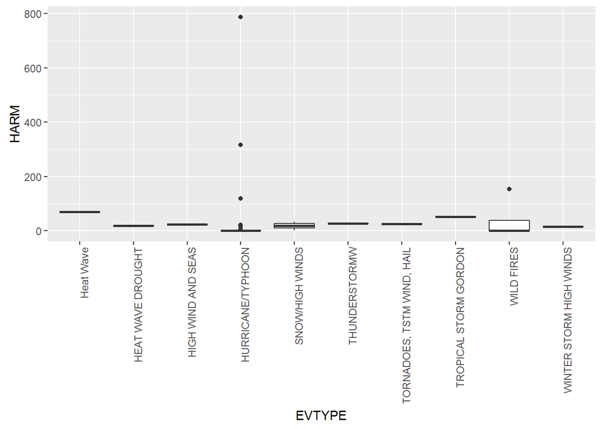

```r
library(ggplot2)
top_storms <- names(sort(means,TRUE))[1:10]
top_10 <- subset(sub_storms, EVTYPE %in% top_storms)
g <- ggplot(top_10,aes(x = EVTYPE, y =HARM)) + geom_boxplot()
g + theme(axis.text.x = element_text(angle = 90, hjust = 1))
```

As the plot shows, there aren’t actually many events going into most of these means and the majority appear to have just a single event. So while we may take away the fact that these are the storms that are most harmful on average, it would be useful to look at which storms are most harmful in total. To do that, let’s sum the number of harmful incidents across each storm type and take a look at the top 20 as before.

```r
sums <- tapply(sub_storms$HARM,sub_storms$EVTYPE,sum,na.rm = TRUE)
head(sort(sums,TRUE),20)
```

```
##            TORNADO     EXCESSIVE HEAT          TSTM WIND
##              96979               8428               7461
##              FLOOD          LIGHTNING               HEAT
##               7259               6046               3037
##        FLASH FLOOD          ICE STORM  THUNDERSTORM WIND
##               2755               2064               1621
##       WINTER STORM          HIGH WIND               HAIL
##               1527               1385               1376
##  HURRICANE/TYPHOON         HEAVY SNOW           WILDFIRE
##               1339               1148                986
## THUNDERSTORM WINDS           BLIZZARD                FOG
##                972                906                796
##        RIP CURRENT   WILD/FOREST FIRE
##                600                557
```

Now we have a very different picture than we did with the averages; we can immediately see that even though tornadoes were not among the top 20 in averge harmful incidents (they were actually #50), they cause the highest total number of harmful incidents by over an order of magnitude. Clearly, tornados kill or injure far more people each year than any of the other events. In fact, if we add the rest of the harmful incidents together, we get a far smaller number than the tornado sum on its own:

```r
sum(sort(sums,TRUE)[-1])
```

```
## [1] 58694
```

By themselves, tornadoes account for nearly twice as many harmful incidents as the rest of the events combined. Putting this together with the averages we examined previously, the data suggest that although individual tornadoes have caused a great deal of harm, the average tornado is not the most harmful storm; rather, heat waves have the highest average number of total injuries plus fatalities. However, tornados harm more people than all of the other storms combined. Thus, while a tornado is unlikely to harm many people, the sheer number of tornado events and handful of very harmful tornadoes mean that they are still the most likely event to cause injuries and fatalities.

### Assessing Economically-Impactful Events

Turning now to economics, we will use our shortened data set to look at property damage. First, let’s look at a summary:

```r
summary(sub_storms$PROPDMG)
```

```
##    Min. 1st Qu.  Median    Mean 3rd Qu.    Max.
##    0.00    0.00    0.00   12.06    0.50 5000.00
```

Similar to the harmful events, the property damage values are mostly 0 and appear to be skewed by some high values at the top; what are the events causing these high values?

```r
head(arrange(sub_storms,desc(PROPDMG)),20)
```

```
##               EVTYPE HARM PROPDMG
## 1  THUNDERSTORM WIND    0    5000
## 2        FLASH FLOOD    0    5000
## 3        FLASH FLOOD    0    5000
## 4         WATERSPOUT    0    5000
## 5          LANDSLIDE    0    4800
## 6            TORNADO    0    4410
## 7  THUNDERSTORM WIND    0    3500
## 8  THUNDERSTORM WIND   25    3200
## 9          HIGH WIND    0    3000
## 10             FLOOD    0    3000
## 11       FLASH FLOOD    0    3000
## 12         LANDSLIDE    0    1584
## 13     COASTAL FLOOD    0    1000
## 14         LIGHTNING    0    1000
## 15           TORNADO    0    1000
## 16       FLASH FLOOD    0    1000
## 17       FLASH FLOOD    0    1000
## 18       FLASH FLOOD    0    1000
## 19       STRONG WIND    0    1000
## 20          WILDFIRE    0    1000
```

We see a variety here, with a bunch of flash floods, some thunderstorm/wind events, and a few others. It’s worth noting that there are only 12 events over the threshold of 1000, and 6 of those 12 are either flash floods or thunderstorm/wind (3 apiece). As we did with harmful events, let us calculate the highest average property damages and also the highest total damages using tapply(). First let us examine the mean values:

```r
means <- tapply(sub_storms$PROPDMG,sub_storms$EVTYPE,mean,na.rm = TRUE)
head(sort(means,TRUE),20)
```

```
##                COASTAL EROSION           HEAVY RAIN AND FLOOD
##                          766.0                          600.0
##         RIVER AND STREAM FLOOD                      Landslump
##                          600.0                          570.0
##          BLIZZARD/WINTER STORM                   FLASH FLOOD/
##                          500.0                          500.0
## FLASH FLOODING/THUNDERSTORM WI              FLOOD/RIVER FLOOD
##                          500.0                          500.0
##                  FROST\\FREEZE            HEAVY PRECIPITATION
##                          500.0                          500.0
##                HEAVY RAIN/SNOW        HEAVY SNOW/WINTER STORM
##                          500.0                          500.0
##                 HIGH WIND/SEAS               HURRICANE GORDON
##                          500.0                          500.0
##                SLEET/ICE STORM             SNOW AND ICE STORM
##                          500.0                          500.0
##                      SNOW/COLD                SNOW/HEAVY SNOW
##                          500.0                          500.0
##          TROPICAL STORM GORDON                     TORNADO F3
##                          500.0                          362.5
```

Before making any sort of plot, let’s do the same for the sums:

```r
sums <- tapply(sub_storms$PROPDMG,sub_storms$EVTYPE,sum,na.rm = TRUE)
head(sort(sums,TRUE),20)
```

```
##              TORNADO          FLASH FLOOD            TSTM WIND
##           3212258.16           1420124.59           1335965.61
##                FLOOD    THUNDERSTORM WIND                 HAIL
##            899938.48            876844.17            688693.38
##            LIGHTNING   THUNDERSTORM WINDS            HIGH WIND
##            603351.78            446293.18            324731.56
##         WINTER STORM           HEAVY SNOW             WILDFIRE
##            132720.59            122251.99             84459.34
##            ICE STORM          STRONG WIND           HIGH WINDS
##             66000.67             62993.81             55625.00
##           HEAVY RAIN       TROPICAL STORM     WILD/FOREST FIRE
##             50842.14             48423.68             39344.95
##       FLASH FLOODING URBAN/SML STREAM FLD
##             28497.15             26051.94
```

Comparing the two lists, we actually see a fair amount of crossover, with a fair number of the highest events being related to floods, winds, and severe winter weather. Once again, tornadoes show up as having the highest cumulative property damage, but are nowhere near the top of the highest averages. We can probably chalk this up, once again, to tornadoes being a particularly common event.

Rather than looking at the means themselves, let’s again construct a box plot to see if we can learn a bit more about the spread of our data.

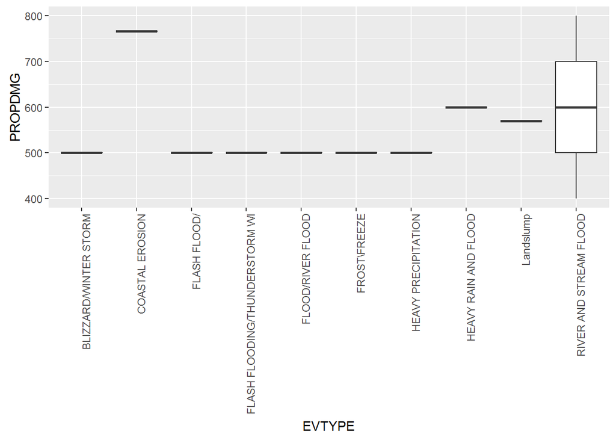

```r
top_storms <- names(sort(means,TRUE))[1:10]
top_10 <- subset(sub_storms, EVTYPE %in% top_storms)
g <- ggplot(top_10,aes(x = EVTYPE, y =PROPDMG)) + geom_boxplot()
g + theme(axis.text.x = element_text(angle = 90, hjust = 1))
```

Much like before, the top average amounts of damage are associated with rare events; the exception here are river and stream floods, which have multiple occurrences and cause a lot of property damage. Let’s now plot our sums, which we just examined above. This time, we don’t expect one particular term to dominate the plot, so it may be more informative than a plot of the total harmful events.

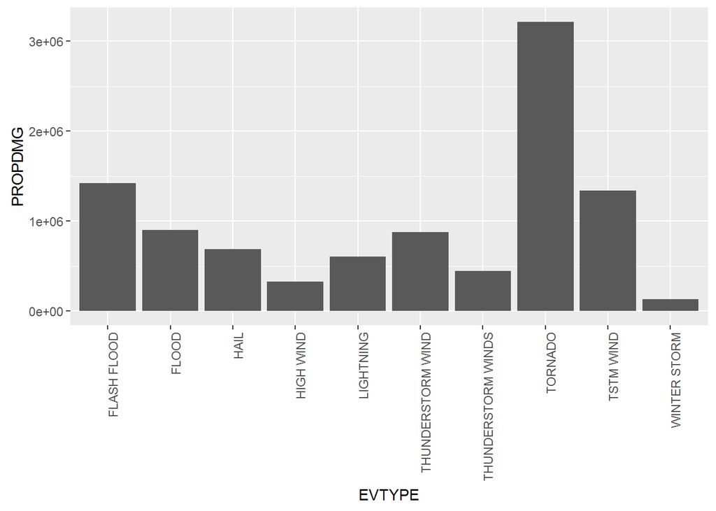

```r
top_storms <- names(sort(sums,TRUE))[1:10]
top_10 <- subset(sub_storms, EVTYPE %in% top_storms)
g <- ggplot(top_10,aes(x = EVTYPE, y =PROPDMG)) + geom_bar(stat = "identity")
g + theme(axis.text.x = element_text(angle = 90, hjust = 1))
```

Although tornadoes still cause the most total property damage, they do not outstrip the other events by a massive amount. Thus, as we summarize this portion of the analysis, our briefly exploration of the data seem to suggest that floods, wind-related events, and winter storms post the greatest danger for inflicting property damage.